# Linux w Systemach Wbudowanych

Piotr Zawadzki

2025-11-23

### Krótkie wprowadzenie do GPIO

GPIO (ang. General Purpose Input/Output) to uniwersalne linie wejścia/wyjścia, które umożliwiają mikrokomputerom komunikację z urządzeniami zewnętrznymi. Na Raspberry Pi linie GPIO pozwalają na odczyt stanów logicznych z czujników, przycisków i innych urządzeń wejściowych, a także na sterowanie diodami LED, silnikami czy przekaźnikami.

### Podstawowe pojęcia i terminologia

Linia GPIO: pojedynczy pin na płytce Raspberry Pi, który może działać jako wejście lub wyjście cyfrowe. Wejście cyfrowe: konfiguracja linii GPIO pozwalająca na odczyt stanu logicznego (wysoki lub niski) urządzenia zewnętrznego. Wyjście cyfrowe: konfiguracja linii GPIO umożliwiająca ustawienie stanu logicznego na pinie w celu sterowania urządzeniem zewnętrznym. Pull-up/Pull-down resistor: rezystory podciągające stosowane w celu zapewnienia stabilnego stanu logicznego linii GPIO, gdy nie jest ona bezpośrednio sterowana. libgpiod: nowoczesne API i zestaw narzędzi użytkowych do obsługi linii GPIO w systemie Linux, zastępujące przestarzały interfejs sysfs. Interfejs sysfs: starszy sposób dostępu do linii GPIO poprzez system plików wirtualnych w Linuxie, obecnie uznawany za przestarzały.

## Narzędzia i API libgpiod

`libgpiod` to nowoczesna biblioteka oraz zestaw narzędzi wiersza poleceń służących do obsługi linii GPIO w systemach Linux. Została stworzona jako następca przestarzałego interfejsu `sysfs` i wykorzystuje nowy interfejs urządzeń znakowych `/dev/gpiochip*`. Dzięki `libgpiod` programiści mogą efektywnie zarządzać liniami GPIO, korzystając z udoskonalonych mechanizmów oferowanych przez jądro systemu Linux.

Aby zainstalować `libgpiod` na Raspberry Pi z systemem Linux, można użyć menedżera pakietów `apt`:

```bash
sudo apt update
sudo apt install -y libgpiod-dev gpiod
```

Spowoduje to zainstalowanie zarówno bibliotek potrzebnych do programowania, jak i narzędzi wiersza poleceń.

### Narzędzia linii komend

Pakiet `gpiod` dostarcza zestaw narzędzi linii komend umożliwiających interakcję z liniami GPIO bez konieczności pisania kodu. Oto najważniejsze z nich:

- `gpiodetect`

  Wyświetla listę dostępnych układów GPIO w systemie.

  ```bash
  gpiodetect
  ```

  Przykładowy wynik:

  ```
  gpiochip0 [pinctrl-bcm2835] (54 lines)
  ```

- `gpioinfo`

  Podaje szczegółowe informacje o liniach GPIO dla wybranego układu.

  ```bash
  gpioinfo gpiochip0
  ```

  Można również wyświetlić informacje o wszystkich układach:

  ```bash
  gpioinfo
  ```

- `gpioset`

  Ustawia stan wyjściowy na wybranych liniach GPIO.

  ```bash
  gpioset gpiochip0 17=1
  ```

  Powyższe polecenie ustawia linię GPIO17 na stan wysoki.
- `gpioget`

  Odczytuje stan linii GPIO skonfigurowanych jako wejścia.

  ```bash
  gpioget gpiochip0 17
  ```

  Zwraca aktualny stan logiczny linii GPIO17.
- `gpiofind`

  Znajduje numer linii GPIO na podstawie jej nazwy.

  ```bash
  gpiofind "GPIO17"
  ```

  Jeśli linia o podanej nazwie istnieje, zwróci jej numer.
- `gpiomon`

  Monitoruje zmiany stanu na wybranych liniach GPIO w czasie rzeczywistym.

  ```bash
  gpiomon gpiochip0 21
  ```

  Można też monitorować wiele linii jednocześnie:

  ```bash
  gpiomon gpiochip0 21 16
  ```

  Polecenie jest szczególnie przydatne podczas debugowania i testowania połączeń GPIO.

### Programowanie z użyciem libgpiod

Biblioteka `libgpiod` udostępnia API dla C, C++ i Python zapewniający interfejs wysokiego poziomu umożliwiający interakcję z liniami GPIO bez konieczności bezpośredniej komunikacji ze sterownikiem kontrolera linii. Dla C++ oferowany jest interfejs obiektowy. Przykład kodu C++ korzystającego z API `libgpiod` zamieszczono poniżej.

```cpp
#include <gpiod.hpp>
#include <iostream>
#include <stdexcept>

int main() {
    try {
        // Otwórz chip GPIO
        gpiod::chip chip{"gpiochip0"};

        // Uzyskaj linię GPIO
        unsigned int line_num = 17;
        auto line = chip.get_line(line_num);

        // Skonfiguruj jako wejście
        line.request({"gpio_input_example",
                     gpiod::line_request::DIRECTION_INPUT,
                     gpiod::line_request::FLAG_BIAS_PULL_UP});

        // Odczytaj wartość
        int value = line.get_value();
        std::cout << "Stan linii GPIO" << line_num << ": " << value << std::endl;

        // Zasoby zostaną automatycznie zwolnione dzięki RAII

    } catch (const std::exception& e) {
        std::cerr << "Błąd: " << e.what() << std::endl;
        return 1;
    }

    return 0;
}
```

Powyższy kod kompiluje komenda:

```bash
g++ -o gpio_input_example gpio_input_example.cpp -lgpiodcxx
```

Główne zalety API C++:

- Obsługa wyjątków zamiast kodów błędów.
- Automatyczne zarządzanie zasobami (RAII).
- Zwięzły i bezpieczny kod dzięki nowoczesnemu API.

### Przestarzały interfejs sysfs

#### Wprowadzenie do sysfs

Interfejs sysfs dla GPIO, dostępny w `/sys/class/gpio/`, był standardowym sposobem kontroli GPIO w Linuxie przed wprowadzeniem `libgpiod`. Jest on obecnie oznaczony jako przestarzały i zostanie usunięty w przyszłych wersjach jądra, zatem należy go unikać w nowo-powstających aplikacjach.

#### Konfiguracja GPIO jako wejścia za pomocą sysfs

Podstawowa ścieżka dostępu do GPIO przez sysfs:

```
/sys/class/gpio/
├── export
├── unexport
└── gpioN/
    ├── direction
    ├── value
    └── edge
```

#### Eksportowanie linii GPIO

Przed użyciem linii GPIO należy ją “wyeksportować”:

```bash
# Eksportowanie GPIO17
echo "17" > /sys/class/gpio/export
```

#### Ustawianie kierunku linii

Po wyeksportowaniu ustawiamy kierunek na wejście:

```bash
echo "in" > /sys/class/gpio/gpio17/direction
```

#### Odczyt stanu linii GPIO

Stan linii można odczytać z pliku `value`:

```bash
cat /sys/class/gpio/gpio17/value
```

#### Przykładowy kod w Bash

```bash
#!/bin/bash

GPIO=17

# Eksportuj GPIO jeśli nie jest już wyeksportowane
if [ ! -d "/sys/class/gpio/gpio$GPIO" ]; then
    echo "$GPIO" > /sys/class/gpio/export
    sleep 0.1
fi

# Ustaw jako wejście
echo "in" > /sys/class/gpio/gpio$GPIO/direction

# Odczytaj wartość
value=$(cat /sys/class/gpio/gpio$GPIO/value)
echo "Stan GPIO$GPIO: $value"

# Zwolnij GPIO
echo "$GPIO" > /sys/class/gpio/unexport
```

#### Przykładowy kod w C++

```cpp
#include <iostream>
#include <fstream>
#include <string>
#include <stdexcept>

class GPIOInput {
private:
    int pin;

public:
    GPIOInput(int gpio_pin) : pin(gpio_pin) {
        export_gpio();
        set_direction();
    }

    ~GPIOInput() {
        unexport_gpio();
    }

    void export_gpio() {
        std::ofstream export_file("/sys/class/gpio/export");
        if (!export_file) throw std::runtime_error("Nie można otworzyć pliku export");
        export_file << pin;
    }

    void set_direction() {
        std::string path = "/sys/class/gpio/gpio" + std::to_string(pin) + "/direction";
        std::ofstream direction_file(path);
        if (!direction_file) throw std::runtime_error("Nie można ustawić kierunku");
        direction_file << "in";
    }

    int read_value() {
        std::string path = "/sys/class/gpio/gpio" + std::to_string(pin) + "/value";
        std::ifstream value_file(path);
        if (!value_file) throw std::runtime_error("Nie można odczytać wartości");
        char value;
        value_file >> value;
        return value - '0';
    }

    void unexport_gpio() {
        std::ofstream unexport_file("/sys/class/gpio/unexport");
        if (!unexport_file) return; // Ignoruj błąd przy zwalnianiu
        unexport_file << pin;
    }
};

int main() {
    try {
        GPIOInput gpio(17);
        std::cout << "Stan GPIO17: " << gpio.read_value() << std::endl;
    } catch (const std::exception& e) {
        std::cerr << "Błąd: " << e.what() << std::endl;
        return 1;
    }
    return 0;
}
```

## Porównanie libgpiod i sysfs

### Zalety i wady obu podejść

#### libgpiod

Zalety:

- Atomowe operacje na liniach GPIO
- Lepsza obsługa współbieżności
- Nowoczesne API w C i C++
- Narzędzia wiersza poleceń
- Możliwość rezerwacji wielu linii w jednej operacji
- Obsługa nazw linii GPIO
- Lepsza wydajność

Wady:

- Wymaga nowszych wersji jądra Linux (≥4.8)
- Mniej dokumentacji i przykładów
- Konieczność linkowania z biblioteką

#### sysfs

Zalety:

- Prosta implementacja
- Łatwy dostęp z poziomu skryptów
- Działa na starszych systemach
- Dobra dokumentacja i wiele przykładów

Wady:

- Przestarzały interfejs
- Brak atomiczności operacji
- Problemy ze współbieżnością
- Niższa wydajność
- Ograniczona funkcjonalność
- Oznaczony jako deprecated

### Przyszłość obsługi GPIO w systemie Linux

- Interfejs sysfs zostanie całkowicie usunięty w przyszłych wersjach jądra
- libgpiod jest oficjalnym następcą i zalecanym interfejsem
- Rozwój libgpiod koncentruje się na:
  - Rozszerzeniu funkcjonalności
  - Poprawie wydajności
  - Lepszej integracji z systemem
  - Wsparciu dla nowych funkcji sprzętowych
- Zalecana migracja do libgpiod dla nowych projektów

Przykład różnicy w kodzie:

```cpp
// libgpiod - nowoczesne podejście
gpiod::chip chip{"gpiochip0"};
auto line = chip.get_line(17);
line.request({"app", gpiod::line_request::DIRECTION_INPUT});
int value = line.get_value();

// sysfs - stare podejście
std::ofstream export_file("/sys/class/gpio/export");
export_file << "17";
std::ofstream direction_file("/sys/class/gpio/gpio17/direction");
direction_file << "in";
std::ifstream value_file("/sys/class/gpio/gpio17/value");
char value;
value_file >> value;
```

### Konfiguracja przycisku chwilowego jako wejścia za pomocą dedykowanego sterownika gpio_keys

#### Koncepcja działania sterownika gpio_keys

Sterownik `gpio_keys` jest częścią jądra Linux, który umożliwia obsługę przycisków podłączonych do linii GPIO jako standardowych urządzeń wejściowych. Sterownik ten mapuje zdarzenia fizyczne (np. wciśnięcie przycisku) na zdarzenia wejściowe systemu Linux, takie jak naciśnięcie klawisza na klawiaturze. Dzięki temu przyciski GPIO mogą być obsługiwane przez standardowe mechanizmy wejściowe systemu, co upraszcza ich integrację z aplikacjami użytkownika.

#### Zasada działania

1. **Definicja przycisku w Device Tree**:
   - Konfiguracja przycisku odbywa się poprzez plik Device Tree (DT), który opisuje sprzęt systemu.
   - W pliku DT definiujemy węzeł `gpio-keys`, który zawiera informacje o przyciskach, takie jak numer GPIO, typ zdarzenia i kod klawisza.
2. **Obsługa zdarzeń przez jądro**:
   - Sterownik `gpio_keys` monitoruje linie GPIO skonfigurowane w DT.
   - Gdy wykryje zmianę stanu (np. wciśnięcie lub zwolnienie przycisku), generuje odpowiednie zdarzenie wejściowe.
   - Zdarzenia te są przekazywane do systemu wejściowego Linux, co pozwala na ich obsługę przez aplikacje użytkownika.
3. **Integracja z systemem wejściowym**:
   - Zdarzenia generowane przez `gpio_keys` są widoczne jako standardowe zdarzenia wejściowe (np. klawisze klawiatury).
   - Aplikacje mogą korzystać z tych zdarzeń bez konieczności bezpośredniego dostępu do GPIO.

#### Przykład konfiguracji w Device Tree

Poniżej znajduje się przykładowa konfiguracja przycisku chwilowego w pliku Device Tree:

```
/ {
    gpio-keys {
        compatible = "gpio-keys";
        pinctrl-names = "default";
        pinctrl-0 = <&pinctrl_gpio_keys>;

        button@0 {
            label = "gpio_button1";
            gpios = <&gpio 17 GPIO_ACTIVE_HIGH>;
            linux,code = <KEY_ENTER>;
            debounce-interval = <10>;
        };

        button@1 {
            label = "gpio_button2";
            gpios = <&gpio 18 GPIO_ACTIVE_HIGH>;
            linux,code = <KEY_ESC>;
            debounce-interval = <10>;
        };
    };
};

&gpio {
    pinctrl_gpio_keys: gpio_keys {
        pinmux = <PINMUX_GPIO_17>, <PINMUX_GPIO_18>;
        bias-pull-down;
    };
};
```

#### Wyjaśnienie konfiguracji

- **Węzeł `gpio-keys`**:
  - `compatible = "gpio-keys";`: Określa, że węzeł jest obsługiwany przez sterownik `gpio_keys`.
  - `pinctrl-names` i `pinctrl-0`: Definiują konfigurację pinów GPIO.
- **Węzeł `button@0` i `button@1`**:
  - `label = "gpio_button1";`: Etykieta pierwszego przycisku.
  - `gpios = <&gpio 17 GPIO_ACTIVE_HIGH>;`: Określa numer GPIO (17) i aktywny stan wysoki dla pierwszego przycisku.
  - `linux,code = <KEY_ENTER>;`: Kod klawisza generowanego przez pierwszy przycisk (np. `KEY_ENTER`).
  - `debounce-interval = <10>;`: Czas *debouncingu* w milisekundach.
  - Analogicznie dla drugiego przycisku (`gpio_button2`, GPIO 18, `KEY_ESC`).
- **Węzeł `&gpio`**:
  - `pinctrl_gpio_keys`: Definiuje konfigurację pinów GPIO.
  - `pinmux = <PINMUX_GPIO_17>, <PINMUX_GPIO_18>;`: Określa, że piny 17 i 18 są używane jako GPIO.
  - `bias-pull-down`: Ustawia rezystor pull-down na pinach GPIO.

Po skompilowaniu definicji sprzętu z pliku źródłowego `*.dts` do pliku binarnego `*.dtb` i jego przekazaniu przez bootloader, jądro systemu inicjuje elementy zgodnie z definicją.

#### Konfiguracja w /boot/firmware/config.txt

Jeżeli w istniejącej definicji Device Tree chcemy zmienić tylko jej fragment nie trzeba kompilować pełnego DT od nowa. Do dyspoazycji mamy mechanizm nakładek które umożliwiają nadpisanie binarnego fragmentu odpowiadającego za konkretny sprzęt. Tradyscyjnie sporządza się plik zawierający konfigurację `*.dts` definiujący nową konfigurację i określający co ma zostać zastąpione. Skompilowaną nakładkę w postaci pliku `*.dto` bootloader podaje się razem z pierwotnym `*.dtb`.

Bootloader Raspberry Pi jest rozprowadzany z zestawem prekompilowanych nakładek. Pewne parametry tych nakładek mogą być określone podczas ich ładowania. Aby załadować nakładkę Device Tree, należy dodać odpowiedni wpis w pliku `/boot/firmware/config.txt`. Poniżej znajduje się przykład konfiguracji dla dwóch przycisków:

```
dtoverlay=gpio-key,gpio=17,active_low=0,gpio_pull=down,label=button1,keycode=28,debounce=10
dtoverlay=gpio-key,gpio=18,active_low=0,gpio_pull=down,label=button2,keycode=1,debounce=10
```

#### Wyjaśnienie konfiguracji w config.txt

- `dtoverlay=gpio-key`: Określa użycie nakładki Device Tree `gpio-key`.
- `gpio=17`: Numer GPIO dla pierwszego przycisku.
- `active_low=0`: Określa, że aktywny stan jest wysoki.
- `gpio_pull=down`: Ustawia rezystor pull-down.
- `label=button1`: Etykieta przycisku.
- `keycode=28`: Kod klawisza generowanego przez pierwszy przycisk (np. `KEY_ENTER`).
- `debounce=10`: Czas debouncingu w milisekundach.
- Analogicznie dla drugiego przycisku (`gpio=18`, `label=button2`, `keycode=1` (np. `KEY_ESC`)).

#### Podsumowanie

Sterownik `gpio_keys` upraszcza obsługę przycisków podłączonych do GPIO, mapując zdarzenia fizyczne na standardowe zdarzenia wejściowe systemu Linux. Konfiguracja odbywa się poprzez plik Device Tree oraz plik `/boot/firmware/config.txt`, co pozwala na łatwą integrację z systemem i aplikacjami użytkownika.

## Popularne urządzenia wejścia

### Przycisk chwilowy (push button)

#### Opis funkcjonalny

Przycisk chwilowy to prosty mechaniczny przełącznik, który łączy dwa styki, gdy jest wciśnięty, i rozłącza je, gdy jest zwolniony. Jest często używany do generowania sygnałów wejściowych w systemach elektronicznych, takich jak uruchamianie funkcji, resetowanie urządzeń czy wprowadzanie danych przez użytkownika.

#### Zasada działania

- W stanie spoczynkowym przycisk jest rozwarty, a GPIO jest połączone z masą (GND) przez rezystor pull-down, co oznacza, że linia GPIO jest w stanie niskim (0).
- Wciśnięcie przycisku powoduje zwarcie styków, co łączy GPIO z napięciem 3.3 V, powodując, że linia GPIO przechodzi w stan wysoki (1).
- Prąd płynie tylko wtedy, gdy przycisk jest wciśnięty, co minimalizuje zużycie energii.

Schemat podłączenia:

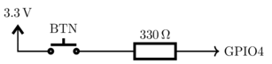

Rys. 3.1 Schemat połączenia przycisku chwilowego zwiernego (*push button normally open*)

#### Przykładowy kod w C++ z wyzwalaniem zboczem

```cpp
#include <gpiod.hpp>

gpiod::chip chip("gpiochip0");
gpiod::line line = chip.get_line(lineNum);
line.request({"button",
       gpiod::line_request::EVENT_BOTH_EDGES
       gpiod::line_request::FLAG_BIAS_PULL_DOWN});
auto event = line.event_wait(std::chrono::milliseconds(100));
if (event) {
   auto event = line.event_read();
   if (event.event_type == gpiod::line_event::RISING_EDGE) {
      // button pressed, see the hardware configuration
   } else {
      // button released
   }
}
// not requirequired because of RAII
// line.release()
```

Gdy przycisk jest skonfigurowany jako `gpio-key`

```
dtoverlay=gpio-key,gpio=4,active_low=0,gpio_pull=down,label=lwsw-key,keycode=16,debounce=200
```

zdarzenia przezeń generowane można odbierać z systemowej kolejki zdarzeń. Aplikacja nie musi wtedy posiadać praw do odczytu stanu linii GPIO. Mówiąc obrazowo, przycisk staje się klawiszem na klawiaturze i tak też należy go w programie traktować.

```cpp
const char* device = "/dev/input/event0";
int fd = open(device, O_RDONLY);
int epoll_fd = epoll_create1(0);

struct epoll_event event;
event.events = EPOLLIN;
event.data.fd = fd;

epoll_ctl(epoll_fd, EPOLL_CTL_ADD, fd, &event)

while (true) {
   struct epoll_event ev;
   int nfds = epoll_wait(epoll_fd, &ev, 1, -1);

   if (nfds > 0 && (ev.events & EPOLLIN)) {
      struct input_event input_ev;
      read(ev.data.fd, &input_ev, sizeof(input_ev));
      std::cout << "Event: time " << input_ev.time.tv_sec << "." << input_ev.time.tv_usec
                  << ", type " << input_ev.type
                  << ", code " << input_ev.code
                  << ", value " << input_ev.value << std::endl;
   }
}

close(fd);
close(epoll_fd);
```

### Enkoder obrotowy (rotary encoder)

#### Opis funkcjonalny

Enkoder obrotowy to urządzenie, które przekształca ruch obrotowy na sygnały elektryczne. Jest używany do precyzyjnego określania pozycji kątowej, kierunku obrotu oraz prędkości obrotowej. Enkodery obrotowe są powszechnie stosowane w interfejsach użytkownika, takich jak pokrętła regulacyjne, oraz w systemach sterowania ruchem.

#### Zasada działania

- Enkoder generuje dwie sekwencje impulsów (CLK/SIA i DT/SIB), które są przesunięte w fazie.
- w zależności od wykrytego zbocza na linii CLK i stanu linii DT tabela dekodowania obrotu jest następująca

| ROT | CCW | CCW | CW | CW |
| --- | --- | --- | --- | --- |
| CLK | rising | falling | rising | falling |
| DT | 0 | 1 | 1 | 0 |

Niektóre enkodery utrzymują linię CLK w stabilnym położeniu, co oznacza, że zdarzenia `rising` and `falling` występują zawsze w parze. Należy wtedy dekodować co drugie zdarzenie, tzn. pominąć kolumnę 3 i 5 tabeli dekodowania.

Sekwencje zdarzeń

- Obrót w prawo (clockwise/CW):
  1. CLK przechodzi z 0 do 1, gdy DT jest 1.
  2. DT przechodzi z 1 do 0.
  3. CLK przechodzi z 1 do 0, gdy DT jest 0.
  4. DT przechodzi z 0 do 1.
- Obrót w lewo (odwrotna sekwencja):
  1. CLK przechodzi z 0 do 1, gdy DT jest 0.
  2. DT przechodzi z 0 do 1.
  3. CLK przechodzi z 1 do 0, gdy DT jest 1.
  4. DT przechodzi z 1 do 0.

Schemat podłączenia:

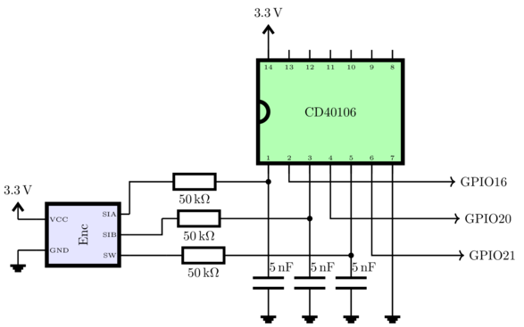

Rys. 3.2 Schemat połączenia enkodera obrotowego wyposażonego w przycisk.

Proszę zauważyć, że przedstawione przebiegi i sekwencje dotyczą sytuacji gdy:

- Enkoder znajduje się na zasilanej płytce zawierającej interfejs elektryczny, dzięki czemu w stanie neutralnym wszystkie sygnały są w stanie wysokim.
- W celu eliminacji “dzwonienia styków” zastosowano filtr dolnoprzepustowy i odwracający przerzutnik Schmitta, zatem na wejściach GPIO w stanie neutralnym mamy stan niski.

#### Przykładowy kod w C++ z wyzwalaniem zboczem

```cpp
#include <gpiod.hpp>

gpiod::chip Schip("gpiochip0");
gpiod::line SIA = chip.get_line(16);
SIA.request(
      "rotary_SIA",
      gpiod::line_request::EVENT_BOTH_EDGES,
      gpiod::line_request::FLAG_BIAS_PULL_DOWN
   );
gpiod::line SIB = chip.get_line(20);
SIB.request(
      "rotary_SIB",
      gpiod::line_request::DIRECTION_INPUT,
      gpiod::line_request::FLAG_BIAS_PULL_DOWN
   );

auto event = SIA.event_wait(std::chrono::milliseconds(10));
if (event) {
      auto SIA_event = SIA_line.event_read();
      int SIB_Value = SIB_line.get_value();
      if (SIA_event.event_type == gpiod::line_event::RISING_EDGE && SIB_Value == 1) {
         // Clockwise rotation
      } else if (SIA_event.event_type == gpiod::line_event::FALLING_EDGE && SIB_Value == 1) { // CounterClockwise rotation
         // decrease the proximity threshold
         auto newThreshold = std::max(appState.proximityThreshold.load() - proximityThresholdDelta,proximityThresholdMin) ;
         appState.proximityThreshold.store(newThreshold) ;
      }
}
```

### Dalmierz akustyczny HC-SR04

#### Opis funkcjonalny

Dalmierz akustyczny HC-SR04 to czujnik odległości, który wykorzystuje ultradźwięki do pomiaru dystansu do obiektu. Jest powszechnie stosowany w robotyce, systemach parkowania oraz w aplikacjach wymagających pomiaru odległości bezkontaktowego.

#### Zasada działania

Schemat podłączenia:

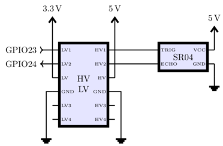

Rys. 3.3 Schemat połączenia dalmierza HC-SR04

#### Przykładowy kod w C++ z wyzwalaniem zboczem

```cpp
#include <gpiod.hpp>

gpiod::chip chip("gpiochip0");
trigger_line = chip.get_line(23);
trigger_line.request(
   "SR04-Trigger"
   ,gpiod::line_request::DIRECTION_OUTPUT
   ,0
   );
trigger_line.set_value(0);
echo_line_ = chip.get_line(24);
echo_line.request(
      "SR04-Echo"
      ,gpiod::line_request::EVENT_BOTH_EDGES
      ,gpiod::line_request::FLAG_BIAS_PULL_DOWN
   );
trigger_line.set_value(1);
usleep(20) ;
trigger_line.set_value(0);

auto rising_time = std::chrono::steady_clock::time_point::min();
auto falling_time = std::chrono::steady_clock::time_point::min();

auto event = echo_line.event_wait(5);
if (event) {
   auto evt = echo_line.event_read();
   if (evt.event_type == gpiod::line_event::RISING_EDGE) {
         // Check if the line value is high
         if (echo_line.get_value() == 1) {
            rising_time = std::chrono::steady_clock::now();
         }
   }
}
auto event = echo_line.event_wait(50);
if (event) {
   auto evt = echo_line.event_read();
   if (evt.event_type == gpiod::line_event::FALLING_EDGE) {
         // Check if the line value is low
         if (echo_line.get_value() == 0) {
            falling_time = std::chrono::steady_clock::now();
         }
   }
}

int duration_us = std::chrono::duration_cast<std::chrono::microseconds>(falling_time - rising_time).count();
double duration_seconds = (1.0*duration_us) / 1'000'000.0;
double speed_of_sound = 343.0; // m/s
auto distance_m = (duration_seconds * speed_of_sound) / 2.0 ; // round trip
```